# Quality of Exercise – Machine Learning Project

Hyun-Joo Kim

January 20, 2018

#### Introcution

Using devices such as Jawbone Up, Nike FuelBand, and Fitbit it is now possible to collect a large amount of data about personal activity relatively inexpensively. These type of devices are part of the quantified self movement - a group of enthusiasts who take measurements about themselves regularly to improve their health, to find patterns in their behavior, or because they are tech geeks. One thing that people regularly do is quantify how much of a particular activity they do, but they rarely quantify how well they do it. They were asked to perform barbell lifts correctly and incorrectly in 5 different ways.

The goal of this project is to develop a classification model from accelerometers on the belt, forearm, arm, and dumbell of 6 participants.

#### Data Reading and Cleaning

```r
trainingdata <- read.csv("G:/My Drive/2016 backups/Work/teaching/Data Science/Coursera/machine learning/pml-training.csv",na.strings=c("NA","#DIV/0!",""))
testingdata <- read.csv("G:/My Drive/2016 backups/Work/teaching/Data Science/Coursera/machine learning/pml-testing (1).csv",na.strings=c("NA","#DIV/0!",""))

trainingdata<-trainingdata[,colSums(is.na(trainingdata))/dim(trainingdata)[1]<0.2]
testingdata<-testingdata[,colSums(is.na(testingdata))/dim(testingdata)[1]<0.2]
```

### Data Exploring

There is more class A exercise than the others. Class B, C, D ,E happened about the same number of the time. Contingency table between class and user name show no obvious pattern. There was no obvious pattern among total numbers and class.

```r
table(trainingdata$classe)
```

```
##
##    A    B    C    D    E
## 5580 3797 3422 3216 3607
```

```r
prop.table(table(trainingdata$classe, trainingdata$user_name),2)
```

```
##
##        adelmo  carlitos   charles    eurico    jeremy     pedro
##   A 0.2993320 0.2679949 0.2542421 0.2817590 0.3459730 0.2452107
##   B 0.1993834 0.2217224 0.2106900 0.1928339 0.1437390 0.1934866
##   C 0.1927030 0.1584190 0.1524321 0.1592834 0.1916520 0.1911877
##   D 0.1323227 0.1561697 0.1815611 0.1895765 0.1534392 0.1796935
##   E 0.1762590 0.1956941 0.2010747 0.1765472 0.1651969 0.1904215
```

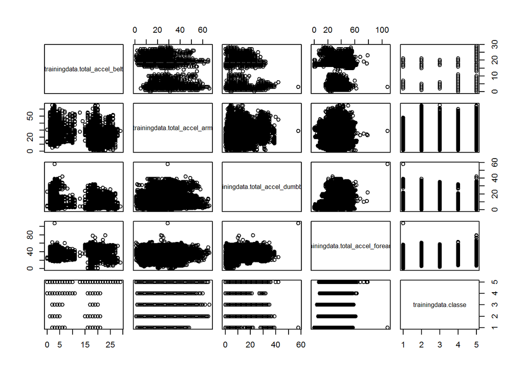

```r
pairs(data.frame(trainingdata$total_accel_belt,trainingdata$total_accel_arm,trainingdata$total_accel_dumbbell,trainingdata$total_accel_forearm, trainingdata$classe))
```

#### Model Building and Prediction Results

The first to sixth variables are eliminated since they are not meaningful predictors. 60% of the data are set as training data and 40% as testing set.

```r
library(caret)
trainingdata<-trainingdata[, -c(1:6)]
testingdata<-testingdata[, -c(1:6)]
inTrain<-createDataPartition(y=trainingdata$classe, p=0.6, list=FALSE)
training<-trainingdata[inTrain,]
testing<-trainingdata[-inTrain,]
```